# Lecture 26 - Into Deep Learning P2

This is an [R Markdown](http://rmarkdown.rstudio.com) Notebook

### Lecture 26 - Your project. Deep Learning with H2O. P.2 Implement on our example

Deep Learning… This lecture is dedicated to the implementation of Deep Learning models into R and in particular **ShinyApp**

#### Work overview (from previous lecture)

- re-arranging data as matrix
- fitting deep learning models
- testing the models
- saving models
- implementation in our ShinyApp…

#### Re-arranging data as a matrix

Let’s get our time - series data as a dataframe first…

```r
library(tidyverse)
# ============= READ DATA =================
# Read our small data ...
DF_Data_Recent <- readRDS("DF_Data_Process_Recent.data")
DF_Equipm <- read_csv("DF_EquipmData.csv")
# data frame containing Event Names
DF_EvCode <- read_csv("DF_EvCodeDataProject.csv")
# Data manipulation and saving to the DF_TEMP
DF_TEMP <- DF_Data_Recent %>%
  # join to decode equipment serial number
  inner_join(DF_Equipm, by = "IDEquipment") %>%
  # join to decode Event Code meaning
  inner_join(DF_EvCode, by = "EventCode") %>%
  # select only column needed
  select(StartDate, Name, AnalogVal, EventText)
```

Then I will plot my data for all 4 machines as just to remember how it looks like…

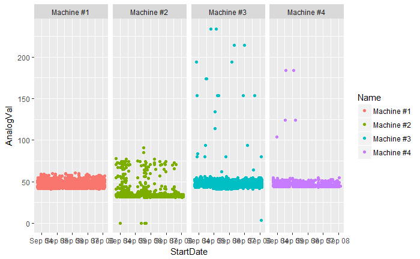

```r
# creating human readable data and visualize them
DF_TEMP %>%
  filter(EventText == "Tubing Process, resistance Ohm") %>%
  ggplot(aes(x = StartDate, y = AnalogVal, col = Name)) + geom_point()+facet_grid(~Name)
```

```r
# extracting only one machine
DF_M1 <- DF_TEMP %>%
  filter(EventText == "Tubing Process, resistance Ohm") %>%
  filter(Name == "Machine #3") %>%
  select(StartDate, AnalogVal) %>%
  head(50)
```

#### Transposing the data

Now we need to **transpose** our data from long to wide structure!

|  | 1 | 2 | 3 | 4 | 5 | 6 | 7 | 8 | 9 | 10 | 11 | 12 | 13 | 14 | 15 | 16 | 17 | 18 | 19 | 20 | 21 | 22 | 23 | 24 | 25 | 26 | 27 | 28 | 29 | … |
| --- | --- | --- | --- | --- | --- | --- | --- | --- | --- | --- | --- | --- | --- | --- | --- | --- | --- | --- | --- | --- | --- | --- | --- | --- | --- | --- | --- | --- | --- | --- |
| StartDate | 2017-09-03 17:44:43 | 2017-09-03 17:44:46 | 2017-09-03 17:44:53 | 2017-09-03 17:47:41 | 2017-09-03 17:46:19 | 2017-09-03 17:46:18 | 2017-09-03 17:47:22 | 2017-09-03 17:47:18 | 2017-09-03 17:47:40 | 2017-09-03 17:48:58 | 2017-09-03 17:49:53 | 2017-09-03 17:48:25 | 2017-09-03 17:48:20 | 2017-09-03 17:48:59 | 2017-09-03 17:54:53 | 2017-09-03 17:59:53 | 2017-09-03 18:04:53 | 2017-09-03 18:05:09 | 2017-09-03 18:07:01 | 2017-09-03 18:15:53 | 2017-09-03 18:18:59 | 2017-09-03 18:29:53 | 2017-09-03 18:39:53 | 2017-09-03 18:09:53 | 2017-09-03 18:34:53 | 2017-09-03 18:31:41 | 2017-09-03 18:32:58 | 2017-09-03 18:24:53 | 2017-09-03 18:15:51 | … |
| AnalogVal | 51 | 45 | 47 | 46 | 46 | 53 | 46 | 52 | 52 | 51 | 47 | 45 | 52 | 45 | 46 | 47 | 49 | 43 | 49 | 45 | 45 | 45 | 46 | 46 | 45 | 45 | 45 | 45 | 51 | … |

```r
DF_M1 <- DF_TEMP %>%
  filter(EventText == "Tubing Process, resistance Ohm") %>%
  filter(Name == "Machine #1") %>%
  select(AnalogVal) %>%
  t() %>%  # this brings us a matrix
  as.vector() %>% # let's make it a vector
  head(3000) %>% # only making fixed amount of rows
  matrix(nrow = 20, ncol = 150) # transforming that into matrix size 25x200
```

Wonderful, let’s try to see! our new object as an image!!!

#### Explore the matrix as a surface!

Let’s use `plotly` 3D graph to explore what we have got!

```r
library(plotly)
plot_ly(z = DF_M1, type = "surface")
```

[interactive chart not shown]

This should be good enough to fit our deep learning model, but before we will do so I will ‘prepare’ my test datasets

A. For machine 2:

```r
DF_M2 <- DF_TEMP %>%
  filter(EventText == "Tubing Process, resistance Ohm") %>%
  filter(Name == "Machine #2") %>%
  select(AnalogVal) %>%
  t() %>%  # this brings us a matrix
  as.vector() %>% # let's make it a vector
  head(1500) %>% # only making fixed amount of rows
  matrix(nrow = 10, ncol = 150) # transforming that into matrix size 25x200
```

B. For machine 3:

```r
DF_M3 <- DF_TEMP %>%
  filter(EventText == "Tubing Process, resistance Ohm") %>%
  filter(Name == "Machine #3") %>%
  select(AnalogVal) %>%
  t() %>%  # this brings us a matrix
  as.vector() %>% # let's make it a vector
  head(3000) %>% # only making fixed amount of rows
  matrix(nrow = 20, ncol = 150) # transforming that into matrix size 25x200
```

And we can also visualize that to confront:

For Machine 2

[interactive chart not shown]

For Machine 3

[interactive chart not shown]

#### Fitting the Deep Learning Model

Launch the machine again…

```r
localH2O = h2o.init()
```

[output not shown]

#### Load datasets to H2O

Then we will download the datasets into h2o. Remember H2O is just operated from R but it’s a computer besides!

```r
# Import train data into the H2O cluster
train_M1 <- as.h2o(x = DF_M1, destination_frame = "train_M1")

# Also import our test datasets for Machines 2 and 3...
test_M2  <- as.h2o(x = DF_M2, destination_frame = "test_M2")
test_M3  <- as.h2o(x = DF_M3, destination_frame = "test_M3")
```

#### Building Deep Learning model with autoencoder

Now, once we know how our data looks like we can start to do our Anomaly Model

```r
# Train deep autoencoder learning model on "normal"
# training data, y ignored
normality_model <- h2o.deeplearning(
 x = names(train_M1),
 training_frame = train_M1,
 activation = "Tanh",
 autoencoder = TRUE,
 hidden = c(50,20,50),
 sparse = TRUE,
 l1 = 1e-4,
 epochs = 100)
```

#### Calculate MSE from the train dataset

Let’s use this model on our training dataset…

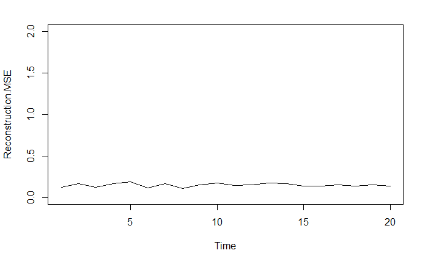

#### Getting to know what AI see:

```r
# visually see it
h2o.anomaly(anomaly_model, train_ecg) %>%
  as.data.frame() %>% plot.ts(ylim = c(0, 2))
```

#### Detect Anomaly using MSE value

Once our model is made, we can use it to detect anomalies in our **test** dataset

```r
# Compute reconstruction error with the Anomaly
# detection app (MSE between output and input layers)
recon_error <- h2o.anomaly(anomaly_model, test_ecg)

# Pull reconstruction error data into R and
# plot to find outliers (last 3 heartbeats)
df_recon_error <- as.data.frame(recon_error)
tail(df_recon_error, 9)
```

[output not shown]

We can plot this as well

```r
plot.ts(df_recon_error)
```

[output not shown]

#### Use Anomaly model to reconstruct Test Dataset

Now we can obtain predictions, or physical values using our model. We should provide the model and test dataset

```r
# Note: Testing = Reconstructing the test dataset
test_recon <- h2o.predict(anomaly_model, test_ecg)
```

In order to make things visible. Once again I ask excel to help… Here I simply write teh dataframe to csv and create graph in excel

```r
# write to csv to use it in excel
test_recon %>% as.data.frame() %>%
write.csv("test_predicted.csv")
```

#### Visualize as 3D

Or we can visualize in 3D directly in R

```r
# making a matrix dataframe
recon_matrix <- test_recon %>% as.data.frame() %>% as.matrix.data.frame()

# make 3D plot
plot_ly(z = recon_matrix, type = "surface")
```

[output not shown]

#### Saving Deep Learning Model for the future use

To use our model in our ShinyApp we will save it…

```r
h2o.saveModel(anomaly_model, "C:/Users/fxtrams/Downloads/tmp/anomaly_model.bin")
h2o.download_pojo(anomaly_model, "C:/Users/fxtrams/Downloads/tmp", get_jar = TRUE)
```

And let’s not forget to switch off our cluster!

```r
h2o.shutdown(prompt= FALSE)
```

```
[1] TRUE
```

#### Conclusion

It learned on the pattern of many vectors and was able to distinguish the anomaly coming on new dataset

Practical use of this model can be to us function **h2o.anomaly**. In case the MSE value will be high - the anomaly is detected!

#### Next step

our next step will be to repeat the procedure but on our machine data.

- re-arranging data as matrix
- fitting deep learning models
- testing the models
- saving models
- implementation in our ShinyApp…

#### used references

example from: (https://dzone.com/articles/anomaly-detection-with-deep-learning-in-r-with-h2o)[https://dzone.com/articles/anomaly-detection-with-deep-learning-in-r-with-h2o]

More reading: (https://dzone.com/articles/the-basics-of-deep-learning-how-to-apply-it-to-pre?fromrel=true)[https://dzone.com/articles/the-basics-of-deep-learning-how-to-apply-it-to-pre?fromrel=true]

And: (https://shiring.github.io/machine_learning/2017/05/01/fraud)[https://shiring.github.io/machine_learning/2017/05/01/fraud]

paper: (https://arxiv.org/abs/1701.01887)[https://arxiv.org/abs/1701.01887] In this lecture we would explore the ‘technology’ on the sample and try to do this in 10 min lecture!